# Report for Egan_&_Yarish__1990

**NOTE**: This data was mined from papers, and was not given to us by the author.

## 1. The Data

Here is your dataset as we reprocessed it. Please take a look.

**Click to see the clean data**

```r
#
 study_data |>
          kable( format = "html") %>%
          kable_styling(position = "center", full_width = F, bootstrap_options = c("striped","hover"))%>%
          scroll_box( width = "1000px", height = "500px", fixed_thead = T)
```

| Entry | Study | Region | Site | Depth.m | Sample.Year | Sample.Month | Sample.Day | Latitude | Longitude | Taxon | Fixed.or.Random | Sample.Unit.Size.sq.m | Percent.Cover | Stipe.Density.num.per.sq.m | Individual.Density.num.per.sq.m | Biomass.kg.wet.per.sq.m |
| --- | --- | --- | --- | --- | --- | --- | --- | --- | --- | --- | --- | --- | --- | --- | --- | --- |
| 129 | Egan_&_Yarish__1990 | USA | southern New England_ Long Island Sound_ Black Ledge | 4 | 1985 | 9 | NA | 41.30302 | -72.08612 | Saccharina longicruris | Random | 0.25 | NA | NA | 40 | 10.0 |
| 130 | Egan_&_Yarish__1990 | USA | southern New England_ Long Island Sound_ Black Ledge | 4 | 1985 | 10 | NA | 41.30302 | -72.08612 | Saccharina longicruris | Random | 0.25 | NA | NA | 35 | 9.0 |
| 131 | Egan_&_Yarish__1990 | USA | southern New England_ Long Island Sound_ Black Ledge | 4 | 1985 | 11 | NA | 41.30302 | -72.08612 | Saccharina longicruris | Random | 0.25 | NA | NA | 34 | 8.0 |
| 132 | Egan_&_Yarish__1990 | USA | southern New England_ Long Island Sound_ Black Ledge | 4 | 1985 | 12 | NA | 41.30302 | -72.08612 | Saccharina longicruris | Random | 0.25 | NA | NA | 30 | 5.5 |
| 133 | Egan_&_Yarish__1990 | USA | southern New England_ Long Island Sound_ Black Ledge | 4 | 1986 | 1 | NA | 41.30302 | -72.08612 | Saccharina longicruris | Random | 0.25 | NA | NA | 31 | 3.0 |
| 134 | Egan_&_Yarish__1990 | USA | southern New England_ Long Island Sound_ Black Ledge | 4 | 1986 | 2 | NA | 41.30302 | -72.08612 | Saccharina longicruris | Random | 0.25 | NA | NA | 39 | 5.0 |
| 135 | Egan_&_Yarish__1990 | USA | southern New England_ Long Island Sound_ Black Ledge | 4 | 1986 | 3 | NA | 41.30302 | -72.08612 | Saccharina longicruris | Random | 0.25 | NA | NA | 22 | 4.0 |
| 136 | Egan_&_Yarish__1990 | USA | southern New England_ Long Island Sound_ Black Ledge | 4 | 1986 | 4 | NA | 41.30302 | -72.08612 | Saccharina longicruris | Random | 0.25 | NA | NA | 100 | 12.0 |
| 137 | Egan_&_Yarish__1990 | USA | southern New England_ Long Island Sound_ Black Ledge | 4 | 1986 | 5 | NA | 41.30302 | -72.08612 | Saccharina longicruris | Random | 0.25 | NA | NA | 175 | 25.0 |
| 138 | Egan_&_Yarish__1990 | USA | southern New England_ Long Island Sound_ Black Ledge | 4 | 1986 | 6 | NA | 41.30302 | -72.08612 | Saccharina longicruris | Random | 0.25 | NA | NA | 1000 | 11.0 |
| 139 | Egan_&_Yarish__1990 | USA | southern New England_ Long Island Sound_ Black Ledge | 4 | 1986 | 7 | NA | 41.30302 | -72.08612 | Saccharina longicruris | Random | 0.25 | NA | NA | 630 | 10.5 |
| 140 | Egan_&_Yarish__1990 | USA | southern New England_ Long Island Sound_ Black Ledge | 4 | 1986 | 8 | NA | 41.30302 | -72.08612 | Saccharina longicruris | Random | 0.25 | NA | NA | 280 | 9.0 |
| 141 | Egan_&_Yarish__1990 | USA | southern New England_ Long Island Sound_ Black Ledge | 4 | 1986 | 9 | NA | 41.30302 | -72.08612 | Saccharina longicruris | Random | 0.25 | NA | NA | 320 | 12.0 |
| 142 | Egan_&_Yarish__1990 | USA | southern New England_ Long Island Sound_ Black Ledge | 4 | 1986 | 10 | NA | 41.30302 | -72.08612 | Saccharina longicruris | Random | 0.25 | NA | NA | 450 | 14.0 |
| 143 | Egan_&_Yarish__1990 | USA | southern New England_ Long Island Sound_ Black Ledge | 4 | 1987 | 1 | NA | 41.30302 | -72.08612 | Saccharina longicruris | Random | 0.25 | NA | NA | 200 | 14.5 |
| 144 | Egan_&_Yarish__1990 | USA | southern New England_ Long Island Sound_ Black Ledge | 4 | 1987 | 5 | NA | 41.30302 | -72.08612 | Saccharina longicruris | Random | 0.25 | NA | NA | 200 | 48.0 |
| 763 | Egan_&_Yarish__1990 | USA | southern New England_ Long Island Sound_ Black Ledge | 4 | 1985 | NA | NA | 41.30302 | -72.08612 | Saccharina longicruris | Random | 0.25 | NA | NA | 40 | 10.0 |
| 764 | Egan_&_Yarish__1990 | USA | southern New England_ Long Island Sound_ Black Ledge | 4 | 1985 | NA | NA | 41.30302 | -72.08612 | Saccharina longicruris | Random | 0.25 | NA | NA | 35 | 9.0 |
| 765 | Egan_&_Yarish__1990 | USA | southern New England_ Long Island Sound_ Black Ledge | 4 | 1985 | NA | NA | 41.30302 | -72.08612 | Saccharina longicruris | Random | 0.25 | NA | NA | 34 | 8.0 |
| 766 | Egan_&_Yarish__1990 | USA | southern New England_ Long Island Sound_ Black Ledge | 4 | 1985 | NA | NA | 41.30302 | -72.08612 | Saccharina longicruris | Random | 0.25 | NA | NA | 30 | 5.5 |
| 767 | Egan_&_Yarish__1990 | USA | southern New England_ Long Island Sound_ Black Ledge | 4 | 1986 | NA | NA | 41.30302 | -72.08612 | Saccharina longicruris | Random | 0.25 | NA | NA | 31 | 3.0 |
| 768 | Egan_&_Yarish__1990 | USA | southern New England_ Long Island Sound_ Black Ledge | 4 | 1986 | NA | NA | 41.30302 | -72.08612 | Saccharina longicruris | Random | 0.25 | NA | NA | 39 | 5.0 |
| 769 | Egan_&_Yarish__1990 | USA | southern New England_ Long Island Sound_ Black Ledge | 4 | 1986 | NA | NA | 41.30302 | -72.08612 | Saccharina longicruris | Random | 0.25 | NA | NA | 22 | 4.0 |
| 770 | Egan_&_Yarish__1990 | USA | southern New England_ Long Island Sound_ Black Ledge | 4 | 1986 | NA | NA | 41.30302 | -72.08612 | Saccharina longicruris | Random | 0.25 | NA | NA | 100 | 12.0 |
| 771 | Egan_&_Yarish__1990 | USA | southern New England_ Long Island Sound_ Black Ledge | 4 | 1986 | NA | NA | 41.30302 | -72.08612 | Saccharina longicruris | Random | 0.25 | NA | NA | 175 | 25.0 |
| 772 | Egan_&_Yarish__1990 | USA | southern New England_ Long Island Sound_ Black Ledge | 4 | 1986 | NA | NA | 41.30302 | -72.08612 | Saccharina longicruris | Random | 0.25 | NA | NA | 1000 | 11.0 |
| 773 | Egan_&_Yarish__1990 | USA | southern New England_ Long Island Sound_ Black Ledge | 4 | 1986 | NA | NA | 41.30302 | -72.08612 | Saccharina longicruris | Random | 0.25 | NA | NA | 630 | 10.5 |
| 774 | Egan_&_Yarish__1990 | USA | southern New England_ Long Island Sound_ Black Ledge | 4 | 1986 | NA | NA | 41.30302 | -72.08612 | Saccharina longicruris | Random | 0.25 | NA | NA | 280 | 9.0 |
| 775 | Egan_&_Yarish__1990 | USA | southern New England_ Long Island Sound_ Black Ledge | 4 | 1986 | NA | NA | 41.30302 | -72.08612 | Saccharina longicruris | Random | 0.25 | NA | NA | 320 | 12.0 |
| 776 | Egan_&_Yarish__1990 | USA | southern New England_ Long Island Sound_ Black Ledge | 4 | 1986 | NA | NA | 41.30302 | -72.08612 | Saccharina longicruris | Random | 0.25 | NA | NA | 450 | 14.0 |
| 777 | Egan_&_Yarish__1990 | USA | southern New England_ Long Island Sound_ Black Ledge | 4 | 1987 | NA | NA | 41.30302 | -72.08612 | Saccharina longicruris | Random | 0.25 | NA | NA | 200 | 14.5 |
| 778 | Egan_&_Yarish__1990 | USA | southern New England_ Long Island Sound_ Black Ledge | 4 | 1987 | NA | NA | 41.30302 | -72.08612 | Saccharina longicruris | Random | 0.25 | NA | NA | 200 | 48.0 |

Here is your dataset as where we have now summed across all kelp species and put into the KelpTime main database format.

**Click to see the data in kelptime format**

```r
#|
kelptime_study |>
         kable( format = "html") %>%
         kable_styling(position = "center", full_width = F, bootstrap_options = c("striped","hover"))%>%
         scroll_box( width = "1000px", height = "500px", fixed_thead = T)
```

| study | site | period | latitude | longitude | sample_unit_size_sq_m | sasdate | max_depth | mean_depth | min_depth | biomass_kg_wet_per_sq_m | stipe_density_num_per_sq_m | individual_density_num_per_sq_m | percent_cover | has_bm | has_sd | has_id | has_pc | use_which | focalKelp | focalUnit | geometry | ecoregion | province | realm | focal_std_by_ecoregion | focal_std_by_province | focal_std_by_realm | ln_focal_std_by_ecoregion | ln_focal_std_by_province | … |
| --- | --- | --- | --- | --- | --- | --- | --- | --- | --- | --- | --- | --- | --- | --- | --- | --- | --- | --- | --- | --- | --- | --- | --- | --- | --- | --- | --- | --- | --- | --- |
| Egan_&_Yarish__1990 | southern New England_ Long Island Sound_ Black Ledge | 1 | 41.30302 | -72.08612 | 0.25 | 1985-06-15 | 4 | 4 | 4 | 8.12500 | 34.7500 | 34.7500 | NA | 18 | 18 | 18 | 0 | 1 | 8.12500 | Biomass | c(-72.086122, 41.30302) | Virginian | Cold Temperate Northwest Atlantic | Temperate Northern Atlantic | 0.2338129 | 0.0326020 | 0.0326020 | -1.4113539 | -3.155855 | … |
| Egan_&_Yarish__1990 | southern New England_ Long Island Sound_ Black Ledge | 2 | 41.30302 | -72.08612 | 0.25 | 1985-09-15 | 4 | 4 | 4 | 10.00000 | 40.0000 | 40.0000 | NA | 18 | 18 | 18 | 0 | 1 | 10.00000 | Biomass | c(-72.086122, 41.30302) | Virginian | Cold Temperate Northwest Atlantic | Temperate Northern Atlantic | 0.2877698 | 0.0401255 | 0.0401255 | -1.2114346 | -2.993225 | … |
| Egan_&_Yarish__1990 | southern New England_ Long Island Sound_ Black Ledge | 3 | 41.30302 | -72.08612 | 0.25 | 1985-10-15 | 4 | 4 | 4 | 9.00000 | 35.0000 | 35.0000 | NA | 18 | 18 | 18 | 0 | 1 | 9.00000 | Biomass | c(-72.086122, 41.30302) | Virginian | Cold Temperate Northwest Atlantic | Temperate Northern Atlantic | 0.2589928 | 0.0361129 | 0.0361129 | -1.3130706 | -3.076662 | … |
| Egan_&_Yarish__1990 | southern New England_ Long Island Sound_ Black Ledge | 4 | 41.30302 | -72.08612 | 0.25 | 1985-11-15 | 4 | 4 | 4 | 8.00000 | 34.0000 | 34.0000 | NA | 18 | 18 | 18 | 0 | 1 | 8.00000 | Biomass | c(-72.086122, 41.30302) | Virginian | Cold Temperate Northwest Atlantic | Temperate Northern Atlantic | 0.2302158 | 0.0321004 | 0.0321004 | -1.4262175 | -3.167698 | … |
| Egan_&_Yarish__1990 | southern New England_ Long Island Sound_ Black Ledge | 5 | 41.30302 | -72.08612 | 0.25 | 1985-12-15 | 4 | 4 | 4 | 5.50000 | 30.0000 | 30.0000 | NA | 18 | 18 | 18 | 0 | 1 | 5.50000 | Biomass | c(-72.086122, 41.30302) | Virginian | Cold Temperate Northwest Atlantic | Temperate Northern Atlantic | 0.1582734 | 0.0220690 | 0.0220690 | -1.7821654 | -3.439865 | … |
| Egan_&_Yarish__1990 | southern New England_ Long Island Sound_ Black Ledge | 6 | 41.30302 | -72.08612 | 0.25 | 1986-01-15 | 4 | 4 | 4 | 3.00000 | 31.0000 | 31.0000 | NA | 18 | 18 | 18 | 0 | 1 | 3.00000 | Biomass | c(-72.086122, 41.30302) | Virginian | Cold Temperate Northwest Atlantic | Temperate Northern Atlantic | 0.0863309 | 0.0120376 | 0.0120376 | -2.3399658 | -3.815003 | … |
| Egan_&_Yarish__1990 | southern New England_ Long Island Sound_ Black Ledge | 7 | 41.30302 | -72.08612 | 0.25 | 1986-02-15 | 4 | 4 | 4 | 5.00000 | 39.0000 | 39.0000 | NA | 18 | 18 | 18 | 0 | 1 | 5.00000 | Biomass | c(-72.086122, 41.30302) | Virginian | Cold Temperate Northwest Atlantic | Temperate Northern Atlantic | 0.1438849 | 0.0200627 | 0.0200627 | -1.8715504 | -3.504469 | … |
| Egan_&_Yarish__1990 | southern New England_ Long Island Sound_ Black Ledge | 8 | 41.30302 | -72.08612 | 0.25 | 1986-03-15 | 4 | 4 | 4 | 4.00000 | 22.0000 | 22.0000 | NA | 18 | 18 | 18 | 0 | 1 | 4.00000 | Biomass | c(-72.086122, 41.30302) | Virginian | Cold Temperate Northwest Atlantic | Temperate Northern Atlantic | 0.1151079 | 0.0160502 | 0.0160502 | -2.0785786 | -3.647730 | … |
| Egan_&_Yarish__1990 | southern New England_ Long Island Sound_ Black Ledge | 9 | 41.30302 | -72.08612 | 0.25 | 1986-04-15 | 4 | 4 | 4 | 12.00000 | 100.0000 | 100.0000 | NA | 18 | 18 | 18 | 0 | 1 | 12.00000 | Biomass | c(-72.086122, 41.30302) | Virginian | Cold Temperate Northwest Atlantic | Temperate Northern Atlantic | 0.3453237 | 0.0481506 | 0.0481506 | -1.0347260 | -2.844719 | … |
| Egan_&_Yarish__1990 | southern New England_ Long Island Sound_ Black Ledge | 10 | 41.30302 | -72.08612 | 0.25 | 1986-05-15 | 4 | 4 | 4 | 25.00000 | 175.0000 | 175.0000 | NA | 18 | 18 | 18 | 0 | 1 | 25.00000 | Biomass | c(-72.086122, 41.30302) | Virginian | Cold Temperate Northwest Atlantic | Temperate Northern Atlantic | 0.7194245 | 0.1003137 | 0.1003137 | -0.3154995 | -2.204427 | … |
| Egan_&_Yarish__1990 | southern New England_ Long Island Sound_ Black Ledge | 11 | 41.30302 | -72.08612 | 0.25 | 1986-06-15 | 4 | 4 | 4 | 10.59091 | 367.9091 | 367.9091 | NA | 18 | 18 | 18 | 0 | 1 | 10.59091 | Biomass | c(-72.086122, 41.30302) | Virginian | Cold Temperate Northwest Atlantic | Temperate Northern Atlantic | 0.3047744 | 0.0424965 | 0.0424965 | -1.1558992 | -2.947008 | … |
| Egan_&_Yarish__1990 | southern New England_ Long Island Sound_ Black Ledge | 12 | 41.30302 | -72.08612 | 0.25 | 1986-07-15 | 4 | 4 | 4 | 10.50000 | 630.0000 | 630.0000 | NA | 18 | 18 | 18 | 0 | 1 | 10.50000 | Biomass | c(-72.086122, 41.30302) | Virginian | Cold Temperate Northwest Atlantic | Temperate Northern Atlantic | 0.3021583 | 0.0421318 | 0.0421318 | -1.1642449 | -2.953981 | … |
| Egan_&_Yarish__1990 | southern New England_ Long Island Sound_ Black Ledge | 13 | 41.30302 | -72.08612 | 0.25 | 1986-08-15 | 4 | 4 | 4 | 9.00000 | 280.0000 | 280.0000 | NA | 18 | 18 | 18 | 0 | 1 | 9.00000 | Biomass | c(-72.086122, 41.30302) | Virginian | Cold Temperate Northwest Atlantic | Temperate Northern Atlantic | 0.2589928 | 0.0361129 | 0.0361129 | -1.3130706 | -3.076662 | … |
| Egan_&_Yarish__1990 | southern New England_ Long Island Sound_ Black Ledge | 14 | 41.30302 | -72.08612 | 0.25 | 1986-09-15 | 4 | 4 | 4 | 12.00000 | 320.0000 | 320.0000 | NA | 18 | 18 | 18 | 0 | 1 | 12.00000 | Biomass | c(-72.086122, 41.30302) | Virginian | Cold Temperate Northwest Atlantic | Temperate Northern Atlantic | 0.3453237 | 0.0481506 | 0.0481506 | -1.0347260 | -2.844719 | … |
| Egan_&_Yarish__1990 | southern New England_ Long Island Sound_ Black Ledge | 15 | 41.30302 | -72.08612 | 0.25 | 1986-10-15 | 4 | 4 | 4 | 14.00000 | 450.0000 | 450.0000 | NA | 18 | 18 | 18 | 0 | 1 | 14.00000 | Biomass | c(-72.086122, 41.30302) | Virginian | Cold Temperate Northwest Atlantic | Temperate Northern Atlantic | 0.4028777 | 0.0561757 | 0.0561757 | -0.8846039 | -2.715442 | … |
| Egan_&_Yarish__1990 | southern New England_ Long Island Sound_ Black Ledge | 16 | 41.30302 | -72.08612 | 0.25 | 1987-01-15 | 4 | 4 | 4 | 14.50000 | 200.0000 | 200.0000 | NA | 18 | 18 | 18 | 0 | 1 | 14.50000 | Biomass | c(-72.086122, 41.30302) | Virginian | Cold Temperate Northwest Atlantic | Temperate Northern Atlantic | 0.4172662 | 0.0581820 | 0.0581820 | -0.8503481 | -2.685575 | … |
| Egan_&_Yarish__1990 | southern New England_ Long Island Sound_ Black Ledge | 17 | 41.30302 | -72.08612 | 0.25 | 1987-05-15 | 4 | 4 | 4 | 48.00000 | 200.0000 | 200.0000 | NA | 18 | 18 | 18 | 0 | 1 | 48.00000 | Biomass | c(-72.086122, 41.30302) | Virginian | Cold Temperate Northwest Atlantic | Temperate Northern Atlantic | 1.3812950 | 0.1926024 | 0.1926024 | 0.3302349 | -1.596510 | … |
| Egan_&_Yarish__1990 | southern New England_ Long Island Sound_ Black Ledge | 18 | 41.30302 | -72.08612 | 0.25 | 1987-06-15 | 4 | 4 | 4 | 31.25000 | 200.0000 | 200.0000 | NA | 18 | 18 | 18 | 0 | 1 | 31.25000 | Biomass | c(-72.086122, 41.30302) | Virginian | Cold Temperate Northwest Atlantic | Temperate Northern Atlantic | 0.8992806 | 0.1253922 | 0.1253922 | -0.0951016 | -1.999580 | … |

## 2. Plots of raw data

### 2.1 By metric

Here is what your data looks like with all sites plotted together looking at each sampling metric.

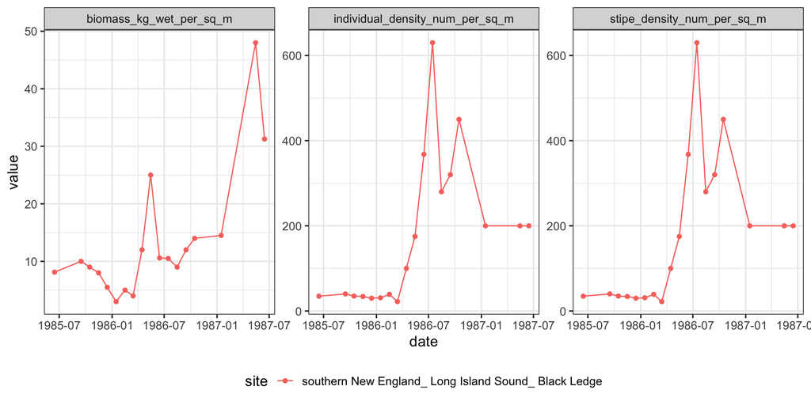

```r
kelptime_study_measurement_long <-
  kelptime_study |>
  tidyr::pivot_longer(cols =biomass_kg_wet_per_sq_m:percent_cover) |>
  filter(!is.na(value))

ggplot(kelptime_study_measurement_long,
       aes(x = date, y = value,
           color = site)) +
  geom_point() +
  geom_line() +
  facet_wrap(vars(name), scale = "free_y")
```

### 2.2 Standardized data

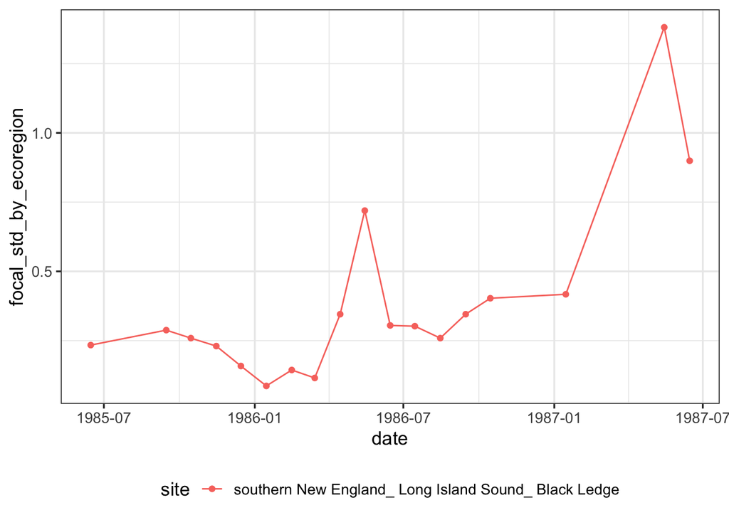

```r
ggplot(kelptime_study,
       aes(x = date, y = focal_std_by_ecoregion,
           color = site)) +
  geom_point() +
  geom_line()
```

### 2.3 Standardized data by site

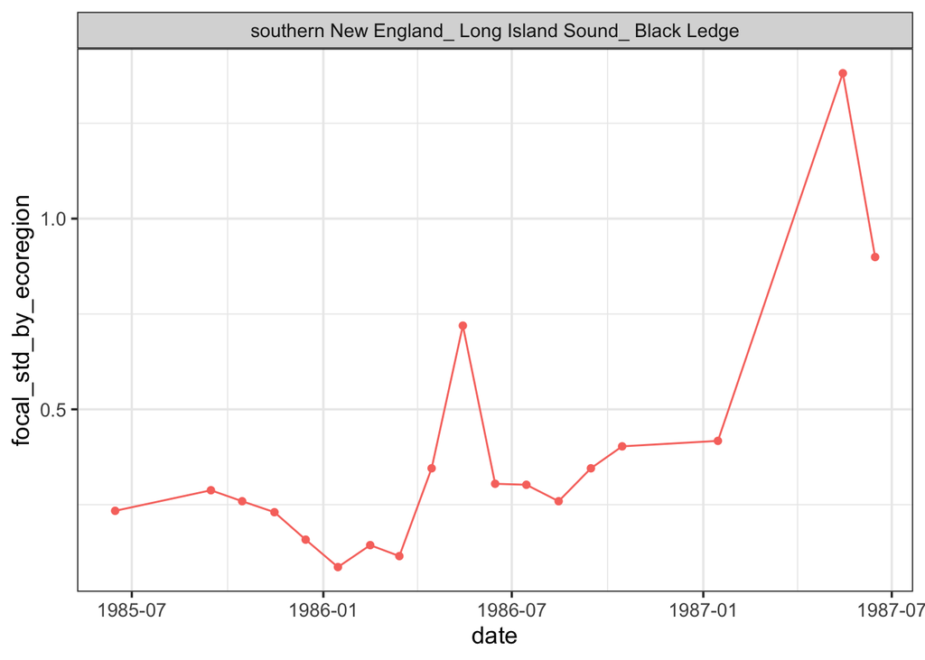

```r
ggplot(kelptime_study,
       aes(x = date, y = focal_std_by_ecoregion,
           color = site)) +
  geom_point() +
  geom_line() +
  facet_wrap(vars(site)) +
  guides(color = "none")
```

## 3. Modeled timeseries resuls

We fit two models. One where the slope varies by ecoregion (note: the GOSL and Newfoundland are collapsed) and one where the slope does not vary by ecoregion. Based on the modeled results, here is the smoothed fits to your data. Note - thus far, the model with a common slope appears to be the correct is the one with a common slope (best fit in terms of prediction and p-value for slope*ecoregion is not distinguishable from 0).

**Note** - the study (black) line might not line up in the middle or on trajectories, as it is shrunken in towards the grand mean for the ecoregion.

### 3.1 Slope Varying by Ecoregion Model

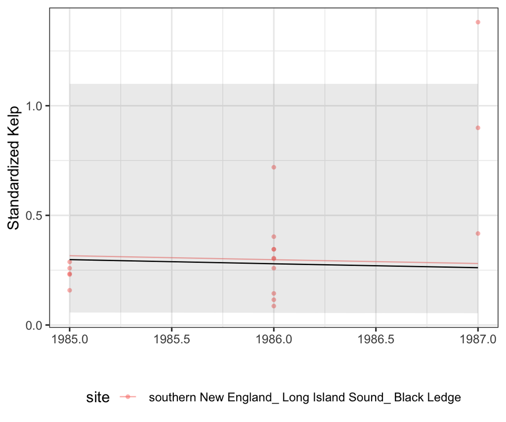

```r
mod_ecoregion <- readRDS("models/mod_ecoregion.rds")


# for plotting to do the back transform
exp_trans <- function(dat){

  dat |>
    mutate(
      Predicted = exp(Predicted)-0.01,
           CI_low = exp(CI_low)-0.01,
           CI_high = exp(CI_high)-0.01,
           CI_high = ifelse(CI_high>1.1, 1.1, CI_high)
    )|>
               mutate(trajectory =
                        gsub(study[1], "", trajectory))

}


re_ecoregion <- ranef(mod_ecoregion)$cond$study |>
  as_tibble(rownames = "study")  |>
  filter(study == params$study) |>
  pull(`(Intercept)`)


dat_fixed_ecoregion <- estimate_relation(mod_ecoregion,
                               include_random = FALSE,
                  length = 200,
                  data = kelptime_study) |>
  mutate(Predicted = Predicted + re_ecoregion,
         CI_high = CI_high + re_ecoregion,
         CI_low = CI_low + re_ecoregion) |>
  exp_trans()

dat_traj_ecoregion <- estimate_relation(mod_ecoregion,
                              include_random = TRUE,
                  length = 200,
                  data = kelptime_study) |>
    exp_trans()


ggplot(dat_traj_ecoregion, aes(x = year)) +
  geom_line(aes(y = Predicted,
                color = trajectory), alpha = 0.5) +
  geom_point(aes(y = focal_std_by_ecoregion,
                 group = trajectory,
                 shape = trajectory,
                 color = trajectory), alpha = 0.5,
             data = kelptime_study |>
               mutate(trajectory =
                        gsub(study[1], "", trajectory))) +
  geom_line(data = dat_fixed_ecoregion,
            aes(y = Predicted), color = "black") +
  geom_ribbon(data = dat_fixed_ecoregion,
            aes(y = Predicted,
                ymin = CI_low,
                ymax = CI_high), color = NA,
            alpha = 0.1) +
  labs(x = "", y = "Standardized Kelp",
      color = "site", shape = "site")
```

### 3.2 Common Slope Model

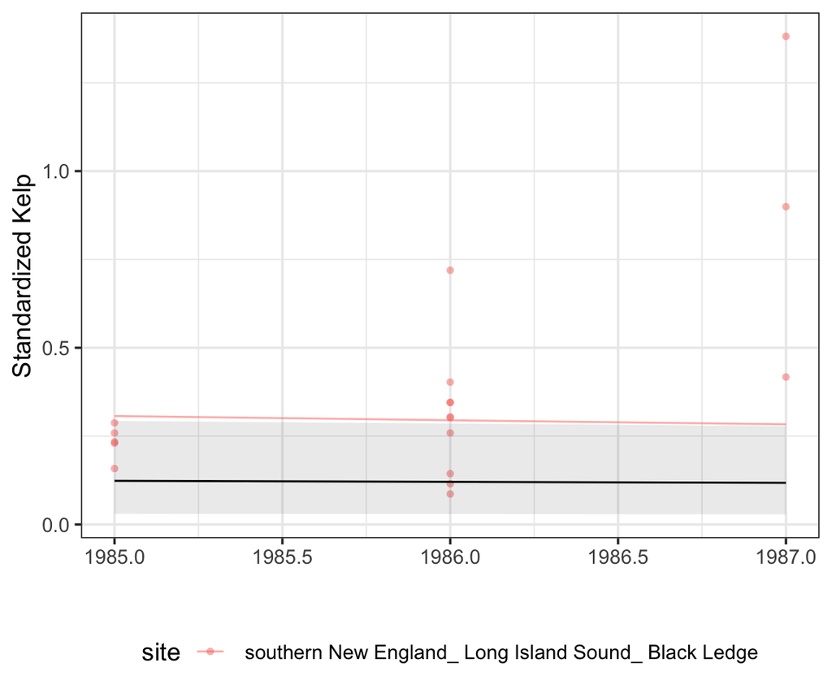

```r
mod_common_slope <- readRDS("models/mod_common_slope.rds")

re <- ranef(mod_common_slope)$cond$study |>
  as_tibble(rownames = "study")  |>
  filter(study == params$study) |>
  pull(`(Intercept)`)


dat_fixed <- estimate_relation(mod_common_slope,
                               include_random = FALSE,
                  length = 200,
                  data = kelptime_study) |>
  mutate(Predicted = Predicted + re,
         CI_high = CI_high + re_ecoregion,
         CI_low = CI_low + re_ecoregion) |>
  exp_trans()

dat_traj <- estimate_relation(mod_common_slope,
                              include_random = TRUE,
                  length = 200,
                  data = kelptime_study) |>
    exp_trans()

ggplot(dat_traj, aes(x = year)) +
  geom_line(aes(y = Predicted,
                color = trajectory), alpha = 0.5) +
  geom_point(aes(y = focal_std_by_ecoregion,
                 group = trajectory,
                 shape = trajectory,
                 color = trajectory), alpha = 0.5,
             data = kelptime_study |>
               mutate(trajectory =
                        gsub(study[1], "", trajectory))) +
  geom_line(data = dat_fixed,
            aes(y = Predicted), color = "black") +
  geom_ribbon(data = dat_fixed,
            aes(y = Predicted,
                ymin = CI_low,
                ymax = CI_high), color = NA,
            alpha = 0.1) +
  labs(x = "", y = "Standardized Kelp",
      color = "site", shape = "site")
```